# Project - Predictive Modeling

## Problem 1: Linear Regression

### Problem Statement:

You are hired by a company Gem Stones co ltd, which is a cubic zirconia manufacturer. You are provided with the dataset containing the prices and other attributes of almost 27,000 cubic zirconia (which is an inexpensive diamond alternative with many of the same qualities as a diamond). The company is earning different profits on different prize slots. You have to help the company in predicting the price for the stone on the bases of the details given in the dataset so it can distinguish between higher profitable stones and lower profitable stones so as to have better profit share. Also, provide them with the best 5 attributes that are most important.

#### Data Dictionary:

1. Carat: Carat weight of the cubic zirconia.
2. Cut: Describe the cut quality of the cubic zirconia. Quality is increasing order Fair, Good, Very Good, Premium, Ideal.
3. Color: Colour of the cubic zirconia.With D being the best and J the worst.
4. Clarity: cubic zirconia Clarity refers to the absence of the Inclusions and Blemishes. (In order from Best to Worst, IF = flawless, l1= level 1 inclusion) IF, VVS1, VVS2, VS1, VS2, Sl1, Sl2, l1
5. Depth: The Height of cubic zirconia, measured from the Culet to the table, divided by its average Girdle Diameter.
6. Table: The Width of the cubic zirconia's Table expressed as a Percentage of its Average Diameter.
7. Price: The Price of the cubic zirconia.
8. X: Length of the cubic zirconia in mm.
9. Y: Width of the cubic zirconia in mm.
10. Z: Height of the cubic zirconia in mm.

```python
# First Let's import all the required libraries and packages

import numpy as np, pandas as pd, matplotlib.pyplot as plt, seaborn as sns
%matplotlib inline
from sklearn.preprocessing import StandardScaler
from sklearn.model_selection import train_test_split
from sklearn.linear_model import LinearRegression
from sklearn import tree
from sklearn.ensemble import RandomForestRegressor
from sklearn.neural_network import MLPRegressor
from sklearn.metrics import mean_squared_error
from sklearn.metrics import mean_absolute_error
from sklearn.model_selection import GridSearchCV
```

### 1.1. Read the data and do exploratory data analysis. Describe the data briefly. (Check the null values, Data types, shape, EDA). Perform Univariate and Bivariate Analysis.

```python
#Reading the dataset

df = pd.read_csv('D:\\SHUBHANK !\\GL\\6. TOPIC 5 - Predictive Modeling\\Final Project\\cubic_zirconia.csv', index_col=[0])

#Checking the head of the dataset

df.head(10)
```

|  | carat | cut | color | clarity | depth | table | x | y | z | price |
| --- | --- | --- | --- | --- | --- | --- | --- | --- | --- | --- |
| 1 | 0.30 | Ideal | E | SI1 | 62.1 | 58.0 | 4.27 | 4.29 | 2.66 | 499 |
| 2 | 0.33 | Premium | G | IF | 60.8 | 58.0 | 4.42 | 4.46 | 2.70 | 984 |
| 3 | 0.90 | Very Good | E | VVS2 | 62.2 | 60.0 | 6.04 | 6.12 | 3.78 | 6289 |
| 4 | 0.42 | Ideal | F | VS1 | 61.6 | 56.0 | 4.82 | 4.80 | 2.96 | 1082 |
| 5 | 0.31 | Ideal | F | VVS1 | 60.4 | 59.0 | 4.35 | 4.43 | 2.65 | 779 |
| 6 | 1.02 | Ideal | D | VS2 | 61.5 | 56.0 | 6.46 | 6.49 | 3.99 | 9502 |
| 7 | 1.01 | Good | H | SI1 | 63.7 | 60.0 | 6.35 | 6.30 | 4.03 | 4836 |
| 8 | 0.50 | Premium | E | SI1 | 61.5 | 62.0 | 5.09 | 5.06 | 3.12 | 1415 |
| 9 | 1.21 | Good | H | SI1 | 63.8 | 64.0 | 6.72 | 6.63 | 4.26 | 5407 |
| 10 | 0.35 | Ideal | F | VS2 | 60.5 | 57.0 | 4.52 | 4.60 | 2.76 | 706 |

```python
#Checking the shape of the data

df.shape
```

```
(26967, 10)
```

```python
#Describing the dataset

df.describe()
```

|  | carat | depth | table | x | y | z | price |
| --- | --- | --- | --- | --- | --- | --- | --- |
| count | 26967.000000 | 26270.000000 | 26967.000000 | 26967.000000 | 26967.000000 | 26967.000000 | 26967.000000 |
| mean | 0.798375 | 61.745147 | 57.456080 | 5.729854 | 5.733569 | 3.538057 | 3939.518115 |
| std | 0.477745 | 1.412860 | 2.232068 | 1.128516 | 1.166058 | 0.720624 | 4024.864666 |
| min | 0.200000 | 50.800000 | 49.000000 | 0.000000 | 0.000000 | 0.000000 | 326.000000 |
| 25% | 0.400000 | 61.000000 | 56.000000 | 4.710000 | 4.710000 | 2.900000 | 945.000000 |
| 50% | 0.700000 | 61.800000 | 57.000000 | 5.690000 | 5.710000 | 3.520000 | 2375.000000 |
| 75% | 1.050000 | 62.500000 | 59.000000 | 6.550000 | 6.540000 | 4.040000 | 5360.000000 |
| max | 4.500000 | 73.600000 | 79.000000 | 10.230000 | 58.900000 | 31.800000 | 18818.000000 |

We can see minimum price is 326 and maximum is 18818. maximum carat is 4.50 and minimum is 0.20.

```python
#Let see some more info

df.info()
```

```
<class 'pandas.core.frame.DataFrame'>
Int64Index: 26967 entries, 1 to 26967
Data columns (total 10 columns):
 #   Column   Non-Null Count  Dtype
---  ------   --------------  -----
 0   carat    26967 non-null  float64
 1   cut      26967 non-null  object
 2   color    26967 non-null  object
 3   clarity  26967 non-null  object
 4   depth    26270 non-null  float64
 5   table    26967 non-null  float64
 6   x        26967 non-null  float64
 7   y        26967 non-null  float64
 8   z        26967 non-null  float64
 9   price    26967 non-null  int64
dtypes: float64(6), int64(1), object(3)
memory usage: 2.3+ MB
```

```python
#What is the shape of the data?

df.shape
```

```
(26967, 10)
```

```python
#Are there any null values present ? Let see.

df.isnull().sum()
```

```
carat        0
cut          0
color        0
clarity      0
depth      697
table        0
x            0
y            0
z            0
price        0
dtype: int64
```

697 null values are present in depth column.

```python
#Let see if there are any duplicate rows in the dataset

df.duplicated().sum()
```

```
34
```

```python
#There are 34 duplicate records found. Let's remove it from the dataset.

df.drop_duplicates(inplace=True)
```

```python
#Let's check the shape again after dropping the duplicates

df.shape
```

```
(26933, 10)
```

```python
#Let's check the data types

df.dtypes
```

```
carat      float64
cut         object
color       object
clarity     object
depth      float64
table      float64
x          float64
y          float64
z          float64
price        int64
dtype: object
```

```python
#Now, let's check the object data types

df.select_dtypes(include='object').head()
```

|  | cut | color | clarity |
| --- | --- | --- | --- |
| 1 | Ideal | E | SI1 |
| 2 | Premium | G | IF |
| 3 | Very Good | E | VVS2 |
| 4 | Ideal | F | VS1 |
| 5 | Ideal | F | VVS1 |

cut, color and clarity are the columns with the object data type.

```python
#Let get some more details about object data type columns:

print('Number of unique values in "cut" variable:',df['cut'].nunique())
print('Those unique values are:',df['cut'].unique())
print('\nValue Counts:\n', df.cut.value_counts())
print('_____________________________________________')
print('Number of unique values in "color" variable:',df['color'].nunique())
print('Those unique values are:',df['color'].unique())
print('\nValue Counts:\n', df.color.value_counts().sort_index(ascending=True))
print('_____________________________________________')
print('Number of unique values in "clarity" variable:',df['clarity'].nunique())
print('Those unique values are:',df['clarity'].unique())
print('\nValue Counts:\n', df.clarity.value_counts())
```

```
Number of unique values in "cut" variable: 5
Those unique values are: ['Ideal' 'Premium' 'Very Good' 'Good' 'Fair']

Value Counts:
 Ideal        10805
Premium       6886
Very Good     6027
Good          2435
Fair           780
Name: cut, dtype: int64
_____________________________________________
Number of unique values in "color" variable: 7
Those unique values are: ['E' 'G' 'F' 'D' 'H' 'J' 'I']

Value Counts:
 D    3341
E    4916
F    4723
G    5653
H    4095
I    2765
J    1440
Name: color, dtype: int64
_____________________________________________
Number of unique values in "clarity" variable: 8
Those unique values are: ['SI1' 'IF' 'VVS2' 'VS1' 'VVS1' 'VS2' 'SI2' 'I1']

Value Counts:
 SI1     6565
VS2     6093
SI2     4564
VS1     4087
VVS2    2530
VVS1    1839
IF       891
I1       364
Name: clarity, dtype: int64
```

'Ideal' quality stones are in majority and 'Fair' quality stones are less.

## Histogram:

```
array([[<AxesSubplot:title={'center':'carat'}>,
        <AxesSubplot:title={'center':'depth'}>],
       [<AxesSubplot:title={'center':'price'}>, <AxesSubplot:>]],
      dtype=object)
```

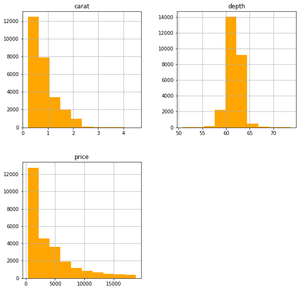

```python
#Creating the histogram for Carat, depth and price.

df[['carat','depth','price']].hist(figsize=(10,10), color='orange')
```

## Countplot:

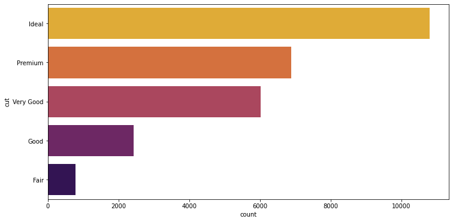

```python
#Lets check the count of cut :

plt.figure(figsize=(12,6))
sns.countplot(y=(df.cut),palette='inferno_r');
```

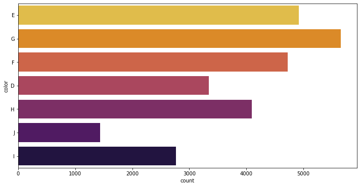

```python
#Lets check the count of different available colors :

plt.figure(figsize=(12,6))
sns.countplot(y=(df.color),palette='inferno_r');
```

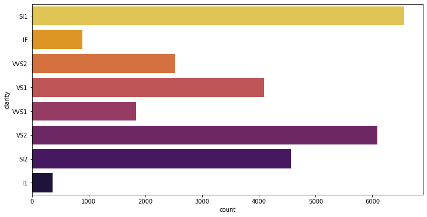

```python
##Lets check the count of different clarity :

plt.figure(figsize=(12,6))
sns.countplot(y=(df.clarity),palette='inferno_r');
```

```python
df.price.describe()
```

```
count    26933.000000
mean      3937.526120
std       4022.551862
min        326.000000
25%        945.000000
50%       2375.000000
75%       5356.000000
max      18818.000000
Name: price, dtype: float64
```

## Barplot

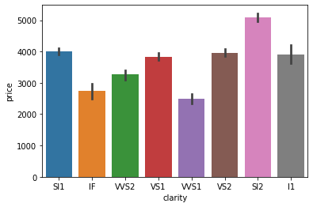

```python
sns.barplot(data = df, x='clarity',y='price')
```

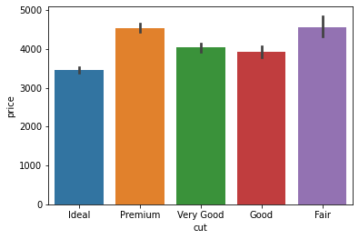

```python
sns.barplot(data = df, x='cut',y='price')
```

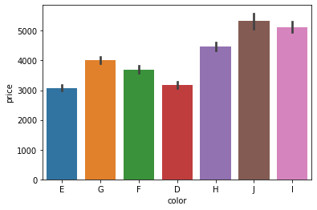

```python
sns.barplot(data = df, x='color',y='price')
```

## Boxplot

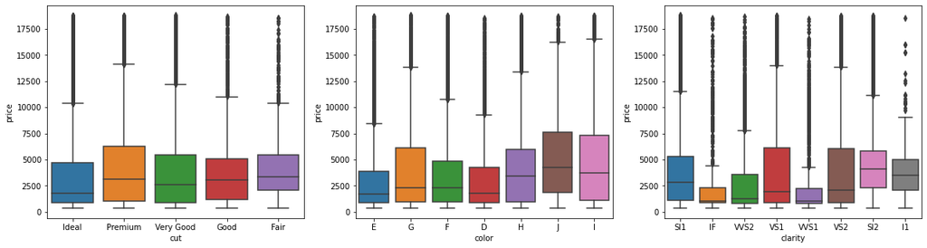

```python
#Let's check the outliers in cut,color, clarity with respect to price variable:

plt.rcParams['figure.figsize']=20,5
plt.subplot(131)
sns.boxplot(df['cut'], df['price'])

plt.subplot(132)
sns.boxplot(df['color'], df['price'])

plt.subplot(133)
sns.boxplot(df['clarity'], df['price'])
plt.show()
```

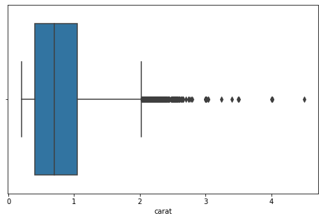

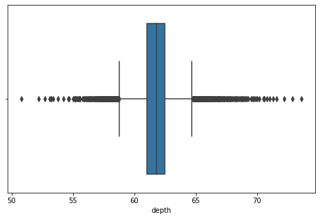

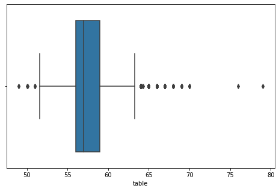

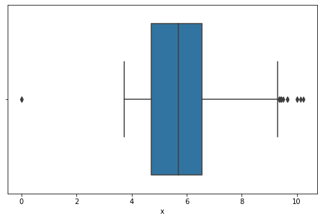

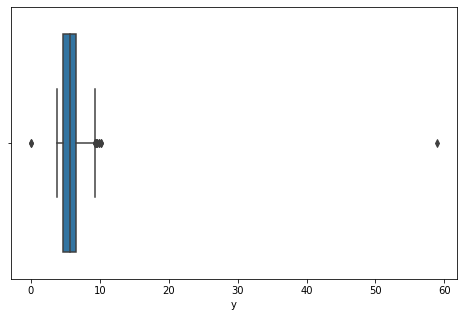

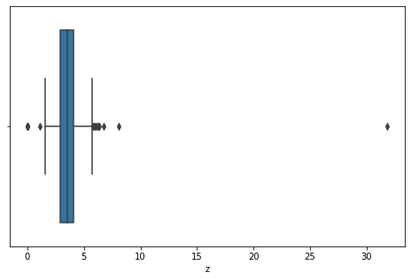

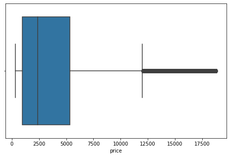

```python
#Let's check the Outliers in all the features

columns = ['carat' ,'depth', 'table', 'x', 'y', 'z',
       'price']


for x in columns:
    plt.figure(figsize=(8,5))
    sns.boxplot(df[x])
    plt.show()
```

## Pairplot

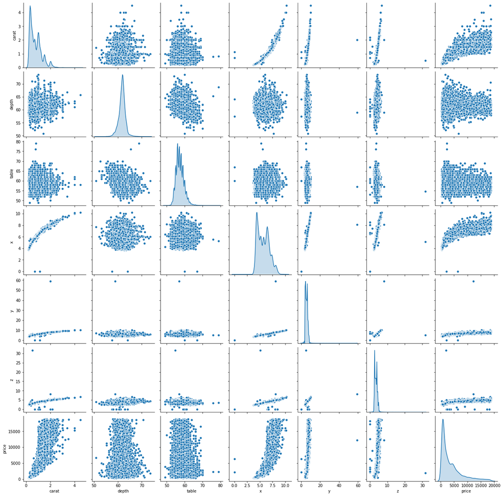

```python
sns.pairplot(df, diag_kind='kde')
plt.show()
```

## Correlation and Heatmap

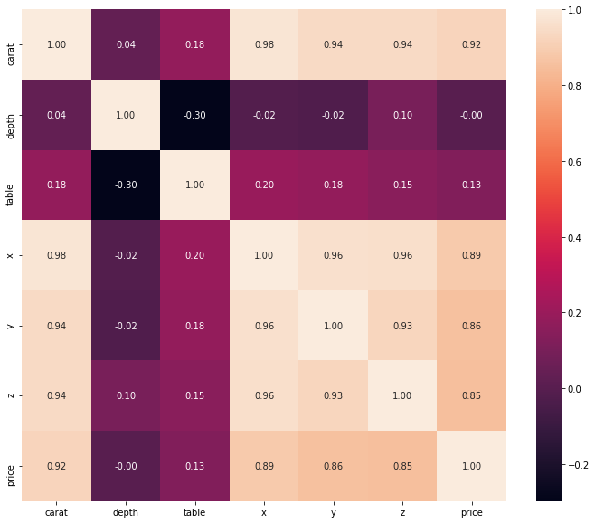

```python
corr = df.corr()
plt.figure(figsize=(12,10))
sns.heatmap(corr, annot=True, fmt = '.2f')
```

### We have given that the X is length , Y is width and Z is height in mm, so let's check whether these factors affecting the price of the product or not.

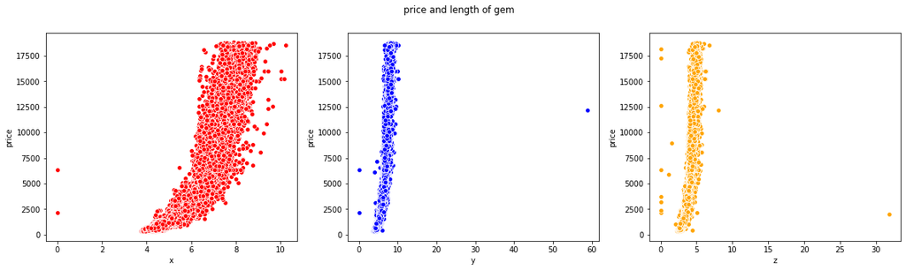

```python
#creating the Scatter plot to see the affect of the dimensions on the product's price

plt.rcParams['figure.figsize']=20,5
plt.subplot(131)
sns.scatterplot(df['x'], df['price'], color='red')

plt.subplot(132)
sns.scatterplot(df['y'], df['price'], color='blue')

plt.subplot(133)
sns.scatterplot(df['z'], df['price'], color='orange')

plt.suptitle('price and length of gem')
plt.show()
```

### 1.2 Impute null values if present, also check for the values which are equal to zero. Do they have any meaning or do we need to change them or drop them? Do you think scaling is necessary in this case?

```python
df.isnull().sum()
```

```
carat        0
cut          0
color        0
clarity      0
depth      697
table        0
x            0
y            0
z            0
price        0
dtype: int64
```

```python
#Let's fill these 697 null place with mean value of depth:

df['depth'].fillna(df['depth'].mean(), inplace=True)

#Again Checking the info

df.isnull().sum()
```

```
carat      0
cut        0
color      0
clarity    0
depth      0
table      0
x          0
y          0
z          0
price      0
dtype: int64
```

## Checking and dropping the zeros from X,Y,Z columns if available:

```python
#Let's check the location of presence of zeros in x,y,z columns

df.loc[((df['x'] == 0) | (df['y'] == 0) | (df['z'] == 0))]
```

|  | carat | cut | color | clarity | depth | table | x | y | z | price |
| --- | --- | --- | --- | --- | --- | --- | --- | --- | --- | --- |
| 5822 | 0.71 | Good | F | SI2 | 64.1 | 60.0 | 0.00 | 0.00 | 0.0 | 2130 |
| 6035 | 2.02 | Premium | H | VS2 | 62.7 | 53.0 | 8.02 | 7.95 | 0.0 | 18207 |
| 10828 | 2.20 | Premium | H | SI1 | 61.2 | 59.0 | 8.42 | 8.37 | 0.0 | 17265 |
| 12499 | 2.18 | Premium | H | SI2 | 59.4 | 61.0 | 8.49 | 8.45 | 0.0 | 12631 |
| 12690 | 1.10 | Premium | G | SI2 | 63.0 | 59.0 | 6.50 | 6.47 | 0.0 | 3696 |
| 17507 | 1.14 | Fair | G | VS1 | 57.5 | 67.0 | 0.00 | 0.00 | 0.0 | 6381 |
| 18195 | 1.01 | Premium | H | I1 | 58.1 | 59.0 | 6.66 | 6.60 | 0.0 | 3167 |
| 23759 | 1.12 | Premium | G | I1 | 60.4 | 59.0 | 6.71 | 6.67 | 0.0 | 2383 |

```python
#Let's drop these rows where zeros are available

df.drop(df[((df['x'] == 0) | (df['y'] == 0) | (df['z'] == 0))].index, inplace=True)
```

```python
#Let's check again

df.loc[((df['x'] == 0) | (df['y'] == 0) | (df['z'] == 0))]
```

|  | carat | cut | color | clarity | depth | table | x | y | z | price |
| --- | --- | --- | --- | --- | --- | --- | --- | --- | --- | --- |

## Scaling the data

```python
#Using standard scaler:

int_type = df.select_dtypes(exclude=['object'])

std_sc = StandardScaler()

#Scaling the integer columnns by fit_transform
df[int_type.columns] = std_sc.fit_transform(int_type)
```

```python
df.head()
```

|  | carat | cut | color | clarity | depth | table | x | y | z | price |
| --- | --- | --- | --- | --- | --- | --- | --- | --- | --- | --- |
| 1 | -1.043484 | Ideal | E | SI1 | 0.254366 | 0.244117 | -1.296010 | -1.240036 | -1.224888 | -0.854844 |
| 2 | -0.980601 | Premium | G | IF | -0.678601 | 0.244117 | -1.162802 | -1.093962 | -1.169137 | -0.734225 |
| 3 | 0.214178 | Very Good | E | VVS2 | 0.326132 | 1.140461 | 0.275843 | 0.332401 | 0.336153 | 0.585129 |
| 4 | -0.791951 | Ideal | F | VS1 | -0.104468 | -0.652227 | -0.807581 | -0.801816 | -0.806752 | -0.709852 |
| 5 | -1.022523 | Ideal | F | VVS1 | -0.965668 | 0.692289 | -1.224966 | -1.119740 | -1.238826 | -0.785208 |

## Removing the outliers:

```python
#Seperating the continuous variables

continuous_variables = df.dtypes[(df.dtypes!='uint8') & (df.dtypes!='object')].index
```

```python
#Defining a function named treat_outliers to removing all the outliers from the continuos variables:

def treat_outliers(col):
    sorted(col)
    Q1,Q3=np.percentile(col,[25,75])
    IQR=Q3-Q1
    lower_range= Q1-(1.5 * IQR)
    upper_range= Q3+(1.5 * IQR)
    return lower_range, upper_range
```

```python
for column in df[continuous_variables].columns:
    lr,ur=treat_outliers(df[column])
    df[column]=np.where(df[column]>ur,ur,df[column])
    df[column]=np.where(df[column]<lr,lr,df[column])
```

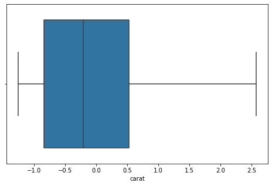

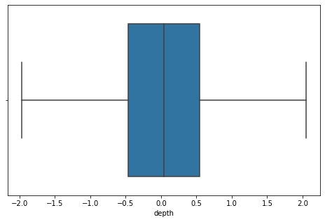

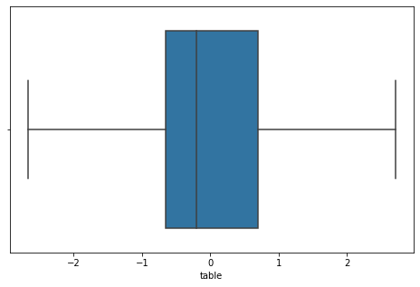

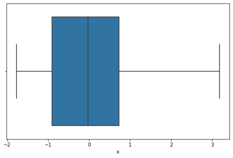

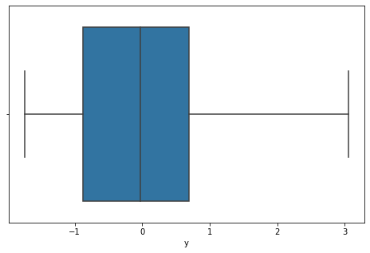

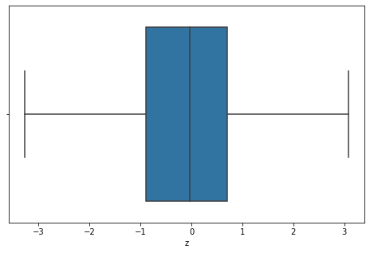

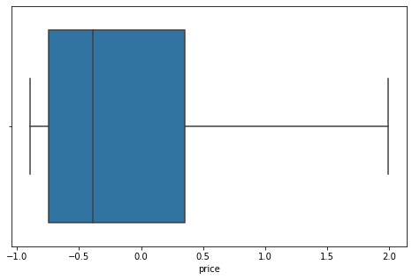

```python
columns = ['carat' ,'depth', 'table', 'x', 'y', 'z',
       'price']

for x in columns:
    plt.figure(figsize=(8,5))
    sns.boxplot(df[x])
    plt.show()
```

## 1.3 Encode the data (having string values) for Modelling. Data Split: Split the data into train and test (70:30). Apply Linear regression. Performance Metrics: Check the performance of Predictions on Train and Test sets using Rsquare, RMSE.

```python
#First we will convert categorical to dummy variables

new_df = pd.get_dummies(df, columns=['cut','color','clarity'],drop_first=True)
```

```python
new_df.head()
```

|  | carat | depth | table | x | y | z | price | cut_Good | cut_Ideal | cut_Premium | ... | color_H | color_I | color_J | clarity_IF | clarity_SI1 | clarity_SI2 | clarity_VS1 | clarity_VS2 | clarity_VVS1 | clarity_VVS2 |
| --- | --- | --- | --- | --- | --- | --- | --- | --- | --- | --- | --- | --- | --- | --- | --- | --- | --- | --- | --- | --- | --- |
| 1 | -1.043484 | 0.254366 | 0.244117 | -1.296010 | -1.240036 | -1.224888 | -0.854844 | 0 | 1 | 0 | ... | 0 | 0 | 0 | 0 | 1 | 0 | 0 | 0 | 0 | 0 |
| 2 | -0.980601 | -0.678601 | 0.244117 | -1.162802 | -1.093962 | -1.169137 | -0.734225 | 0 | 0 | 1 | ... | 0 | 0 | 0 | 1 | 0 | 0 | 0 | 0 | 0 | 0 |
| 3 | 0.214178 | 0.326132 | 1.140461 | 0.275843 | 0.332401 | 0.336153 | 0.585129 | 0 | 0 | 0 | ... | 0 | 0 | 0 | 0 | 0 | 0 | 0 | 0 | 0 | 1 |
| 4 | -0.791951 | -0.104468 | -0.652227 | -0.807581 | -0.801816 | -0.806752 | -0.709852 | 0 | 1 | 0 | ... | 0 | 0 | 0 | 0 | 0 | 0 | 1 | 0 | 0 | 0 |
| 5 | -1.022523 | -0.965668 | 0.692289 | -1.224966 | -1.119740 | -1.238826 | -0.785208 | 0 | 1 | 0 | ... | 0 | 0 | 0 | 0 | 0 | 0 | 0 | 0 | 1 | 0 |

5 rows × 24 columns

```python
#Let's rename few columns for better readability

new_df.rename(columns = {'cut_Very Good' : 'cut_Very_Good'}, inplace = True)
```

### Spliting the dataset into Train and Test set

```python
#'Price' is the Target Variable:

X = new_df.drop('price', axis=1)
y = new_df[['price']]
```

```python
#As given in the question, Split train and test into 70:30

X_train, X_test, y_train, y_test = train_test_split(X, y, test_size=0.3 , random_state=1)
```

```python
#Now let's fit the X_train and y_train into the model

reg_model = LinearRegression()

reg_model.fit(X_train, y_train)
```

```
LinearRegression()
```

### Checking score on train and test data

```python
#Let's check the score for train data

reg_model.score(X_train, y_train)
```

```
0.9404719027464119
```

```python
#Let's check the score for test data

reg_model.score(X_test, y_test)
```

```
0.9416169664411843
```

### Checking RMSE on train and test data

```python
#Check RMSE on train data

from sklearn import metrics

predicted_train=reg_model.fit(X_train, y_train).predict(X_train)

np.sqrt(metrics.mean_squared_error(y_train,predicted_train))
```

```
0.20984203003055799
```

```python
#Check RMSE on test data

predicted_test=reg_model.fit(X_train, y_train).predict(X_test)

np.sqrt(metrics.mean_squared_error(y_test,predicted_test))
```

```
0.20942733183439705
```

### Checking the coefficients

```python
for idx, column in enumerate(X_train.columns):
    print("Coefficient for {} is {}".format(column, reg_model.coef_[0][idx]))
```

```
Coefficient for carat is 1.091608986444096
Coefficient for depth is 0.004292589689086406
Coefficient for table is -0.01280995363087446
Coefficient for x is -0.3297283160277515
Coefficient for y is 0.31326746642933856
Coefficient for z is -0.11428048662800115
Coefficient for cut_Good is 0.09632120352750682
Coefficient for cut_Ideal is 0.1566526304064449
Coefficient for cut_Premium is 0.1488898790105733
Coefficient for cut_Very_Good is 0.12494507083633381
Coefficient for color_E is -0.04697340540558105
Coefficient for color_F is -0.05750774333969632
Coefficient for color_G is -0.10223606541857169
Coefficient for color_H is -0.20679844309213313
Coefficient for color_I is -0.3308004746003582
Coefficient for color_J is -0.4629825913578346
Coefficient for clarity_IF is 0.9936103167577837
Coefficient for clarity_SI1 is 0.6306802090826207
Coefficient for clarity_SI2 is 0.42581742996624716
Coefficient for clarity_VS1 is 0.8344180308840299
Coefficient for clarity_VS2 is 0.7640466334789668
Coefficient for clarity_VVS1 is 0.9393141121734576
Coefficient for clarity_VVS2 is 0.9367999621686632
```

```python
# Let us check the intercept for the model

intercept = reg_model.intercept_[0]

print("The intercept for our model is {}".format(intercept))
```

```
The intercept for our model is -0.7571488566897918
```

### Linear Regression using statsmodels

```python
# Concatenate X and y into a single dataframe:

data_train = pd.concat([X_train, y_train], axis=1)
data_test  = pd.concat([X_test,y_test],axis=1)
```

```python
data_train.head()
```

|  | carat | depth | table | x | y | z | cut_Good | cut_Ideal | cut_Premium | cut_Very_Good | ... | color_I | color_J | clarity_IF | clarity_SI1 | clarity_SI2 | clarity_VS1 | clarity_VS2 | clarity_VVS1 | clarity_VVS2 | price |
| --- | --- | --- | --- | --- | --- | --- | --- | --- | --- | --- | --- | --- | --- | --- | --- | --- | --- | --- | --- | --- | --- |
| 5031 | 0.633398 | 1.115566 | -0.652227 | 0.710988 | 0.727658 | 0.851854 | 1 | 0 | 0 | 0 | ... | 0 | 0 | 0 | 0 | 1 | 0 | 0 | 0 | 0 | 0.032020 |
| 12109 | 0.444749 | 1.617933 | -0.652227 | 0.506736 | 0.555807 | 0.726413 | 0 | 0 | 0 | 1 | ... | 0 | 0 | 0 | 0 | 1 | 0 | 0 | 0 | 0 | 0.305839 |
| 20182 | -0.267926 | -0.750368 | 1.767902 | -0.114900 | -0.080041 | -0.179548 | 1 | 0 | 0 | 0 | ... | 1 | 0 | 0 | 0 | 0 | 0 | 1 | 0 | 0 | -0.554166 |
| 4713 | -0.079277 | -1.970402 | 2.484977 | 0.284723 | 0.203513 | -0.095921 | 1 | 0 | 0 | 0 | ... | 0 | 0 | 0 | 1 | 0 | 0 | 0 | 0 | 0 | -0.370376 |
| 2549 | 0.444749 | 0.756732 | 0.692289 | 0.568900 | 0.521437 | 0.628848 | 0 | 0 | 1 | 0 | ... | 0 | 0 | 0 | 0 | 0 | 1 | 0 | 0 | 0 | 0.666951 |

5 rows × 24 columns

```python
data_train.columns
```

```
Index(['carat', 'depth', 'table', 'x', 'y', 'z', 'cut_Good', 'cut_Ideal',
       'cut_Premium', 'cut_Very_Good', 'color_E', 'color_F', 'color_G',
       'color_H', 'color_I', 'color_J', 'clarity_IF', 'clarity_SI1',
       'clarity_SI2', 'clarity_VS1', 'clarity_VS2', 'clarity_VVS1',
       'clarity_VVS2', 'price'],
      dtype='object')
```

```python
expr = 'price ~ carat + depth + table + x+ y + z + cut_Good + cut_Ideal + cut_Premium + cut_Very_Good + color_E + color_F + color_G + color_H + color_I + color_J + clarity_IF + clarity_SI1 + clarity_SI2 + clarity_VS1 + clarity_VS2 + clarity_VVS1 + clarity_VVS2'
```

```python
import statsmodels.formula.api as smf

lm1 = smf.ols(formula= expr, data = data_train).fit()

lm1.params
```

```
Intercept       -0.757149
carat            1.091609
depth            0.004293
table           -0.012810
x               -0.329728
y                0.313267
z               -0.114280
cut_Good         0.096321
cut_Ideal        0.156653
cut_Premium      0.148890
cut_Very_Good    0.124945
color_E         -0.046973
color_F         -0.057508
color_G         -0.102236
color_H         -0.206798
color_I         -0.330800
color_J         -0.462983
clarity_IF       0.993610
clarity_SI1      0.630680
clarity_SI2      0.425817
clarity_VS1      0.834418
clarity_VS2      0.764047
clarity_VVS1     0.939314
clarity_VVS2     0.936800
dtype: float64
```

```python
print(lm1.summary())
```

```
                            OLS Regression Results
==============================================================================
Dep. Variable:                  price   R-squared:                       0.940
Model:                            OLS   Adj. R-squared:                  0.940
Method:                 Least Squares   F-statistic:                 1.293e+04
Date:                Sat, 31 Jul 2021   Prob (F-statistic):               0.00
Time:                        20:48:47   Log-Likelihood:                 2685.0
No. Observations:               18847   AIC:                            -5322.
Df Residuals:                   18823   BIC:                            -5134.
Df Model:                          23
Covariance Type:            nonrobust
=================================================================================
                    coef    std err          t      P>|t|      [0.025      0.975]
---------------------------------------------------------------------------------
Intercept        -0.7571      0.016    -46.528      0.000      -0.789      -0.725
carat             1.0916      0.009    118.886      0.000       1.074       1.110
depth             0.0043      0.004      1.184      0.237      -0.003       0.011
table            -0.0128      0.002     -6.021      0.000      -0.017      -0.009
x                -0.3297      0.038     -8.626      0.000      -0.405      -0.255
y                 0.3133      0.040      7.835      0.000       0.235       0.392
z                -0.1143      0.023     -4.886      0.000      -0.160      -0.068
cut_Good          0.0963      0.011      8.796      0.000       0.075       0.118
cut_Ideal         0.1567      0.011     14.701      0.000       0.136       0.178
cut_Premium       0.1489      0.010     14.582      0.000       0.129       0.169
cut_Very_Good     0.1249      0.011     11.898      0.000       0.104       0.146
color_E          -0.0470      0.006     -8.318      0.000      -0.058      -0.036
color_F          -0.0575      0.006    -10.046      0.000      -0.069      -0.046
color_G          -0.1022      0.006    -18.267      0.000      -0.113      -0.091
color_H          -0.2068      0.006    -34.647      0.000      -0.218      -0.195
color_I          -0.3308      0.007    -49.715      0.000      -0.344      -0.318
color_J          -0.4630      0.008    -56.819      0.000      -0.479      -0.447
clarity_IF        0.9936      0.016     61.555      0.000       0.962       1.025
clarity_SI1       0.6307      0.014     45.631      0.000       0.604       0.658
clarity_SI2       0.4258      0.014     30.639      0.000       0.399       0.453
clarity_VS1       0.8344      0.014     59.087      0.000       0.807       0.862
clarity_VS2       0.7640      0.014     54.934      0.000       0.737       0.791
clarity_VVS1      0.9393      0.015     62.758      0.000       0.910       0.969
clarity_VVS2      0.9368      0.015     64.387      0.000       0.908       0.965
==============================================================================
Omnibus:                     4642.691   Durbin-Watson:                   2.002
Prob(Omnibus):                  0.000   Jarque-Bera (JB):            17342.712
Skew:                           1.197   Prob(JB):                         0.00
Kurtosis:                       7.043   Cond. No.                         67.8
==============================================================================

Warnings:
[1] Standard Errors assume that the covariance matrix of the errors is correctly specified.
```

```python
# Calculate MSE
MSE = np.mean((lm1.predict(data_train.drop('price',axis=1))-data_train['price'])**2)
print('Mean Square Error:',MSE)
print('_________________________')
#Root Mean Squared Error - RMSE
print('Root mean square error:',np.sqrt(MSE))
```

```
Mean Square Error: 0.04403367756734561
_________________________
Root mean square error: 0.209842030030558
```

```python
#model score

reg_model.score(X_test, y_test)
```

```
0.9416169664411843
```

```python
y_pred = reg_model.predict(X_test)
```

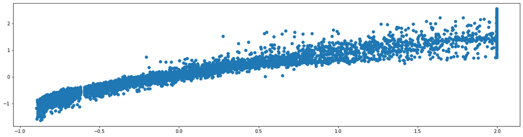

```python
plt.scatter(y_test['price'], y_pred)
plt.show()
```

```python
for i,j in np.array(lm1.params.reset_index()):
    print('({}) * {} +'.format(round(j,2),i),end=' ')
```

[output not shown]

## 1.4 Inference: Basis on these predictions, what are the business insights and recommendations.

#### Recommendations:

1) TOP LEVEL CUT. Based on the above few observations from the concluded result, we can say that cut and clarity holds the power of growing the profits for the company and that is the biggest benefit, because the upper level cuts like Ideal cut, premium cut and the very_good type of cut captures the higher contribution towards the company's growth, and so i recommend that we should display and prioritize those 3 cuts and company should make the best marketing strategy to boost the sales of these stones.

2) BETTER THE QUALITY, MORE THE PROFIT. Also, I can see that the clarity of the stones holds the power to boost the profit for the company. So I recommend that the company should focus more on the stone's clarity, because better the clarity, more the profit.

**_** THE END **__**

## Problem 2: Logistic Regression and LDA

#### Problem Statement:

You are hired by a tour and travel agency which deals in selling holiday packages. You are provided details of 872 employees of a company. Among these employees, some opted for the package and some didn't. You have to help the company in predicting whether an employee will opt for the package or not on the basis of the information given in the data set. Also, find out the important factors on the basis of which the company will focus on particular employees to sell their packages.

#### Data Dictionary:

1. Holiday_Package: Opted for Holiday Package yes/no?
2. Salary: Employee salary
3. age: Age in years
4. edu: Years of formal education
5. no_young_children: The number of young children (younger than 7 years)
6. no_older_children: Number of older children
7. foreign: foreigner Yes/No

```python
import numpy as np, pandas as pd, seaborn as sns, matplotlib.pyplot as plt
from sklearn.model_selection import train_test_split,GridSearchCV
from sklearn.linear_model import LogisticRegression
from sklearn import metrics
from sklearn.metrics import roc_auc_score,roc_curve,classification_report,confusion_matrix,plot_confusion_matrix
```

### 2.1 Data Ingestion: Read the dataset. Do the descriptive statistics and do null value condition check, write an inference on it. Perform Univariate and Bivariate Analysis. Do exploratory data analysis.

### Loading and Reading the dataset

```python
holiday = pd.read_csv('D:\\SHUBHANK !\\GL\\6. TOPIC 5 - Predictive Modeling\\Final Project\\Holiday_Package.csv', index_col=[0])

holiday
```

|  | Holliday_Package | Salary | age | educ | no_young_children | no_older_children | foreign |
| --- | --- | --- | --- | --- | --- | --- | --- |
| 1 | no | 48412 | 30 | 8 | 1 | 1 | no |
| 2 | yes | 37207 | 45 | 8 | 0 | 1 | no |
| 3 | no | 58022 | 46 | 9 | 0 | 0 | no |
| 4 | no | 66503 | 31 | 11 | 2 | 0 | no |
| 5 | no | 66734 | 44 | 12 | 0 | 2 | no |
| ... | ... | ... | ... | ... | ... | ... | ... |
| 868 | no | 40030 | 24 | 4 | 2 | 1 | yes |
| 869 | yes | 32137 | 48 | 8 | 0 | 0 | yes |
| 870 | no | 25178 | 24 | 6 | 2 | 0 | yes |
| 871 | yes | 55958 | 41 | 10 | 0 | 1 | yes |
| 872 | no | 74659 | 51 | 10 | 0 | 0 | yes |

872 rows × 7 columns

### Let's rename the column first for better readability

```python
holiday.rename(columns = {'Holliday_Package':'Holiday_Package','age':'Age', 'educ':'Education(In Years)', 'no_young_children':'Num_Young_Children(<7 yrs)', 'no_older_children':'Num_Older_Children', 'foreign':'Foreign'}, inplace=True)
```

```python
holiday
```

|  | Holiday_Package | Salary | Age | Education(In Years) | Num_Young_Children(<7 yrs) | Num_Older_Children | Foreign |
| --- | --- | --- | --- | --- | --- | --- | --- |
| 1 | no | 48412 | 30 | 8 | 1 | 1 | no |
| 2 | yes | 37207 | 45 | 8 | 0 | 1 | no |
| 3 | no | 58022 | 46 | 9 | 0 | 0 | no |
| 4 | no | 66503 | 31 | 11 | 2 | 0 | no |
| 5 | no | 66734 | 44 | 12 | 0 | 2 | no |
| ... | ... | ... | ... | ... | ... | ... | ... |
| 868 | no | 40030 | 24 | 4 | 2 | 1 | yes |
| 869 | yes | 32137 | 48 | 8 | 0 | 0 | yes |
| 870 | no | 25178 | 24 | 6 | 2 | 0 | yes |
| 871 | yes | 55958 | 41 | 10 | 0 | 1 | yes |
| 872 | no | 74659 | 51 | 10 | 0 | 0 | yes |

872 rows × 7 columns

```python
#Let's check the shape

print('No. of rows:',holiday.shape[0])
print('No. of columns:',holiday.shape[1])
```

```
No. of rows: 872
No. of columns: 7
```

```python
#Description about the dataset

holiday.describe()
```

|  | Salary | Age | Education(In Years) | Num_Young_Children(<7 yrs) | Num_Older_Children |
| --- | --- | --- | --- | --- | --- |
| count | 872.000000 | 872.000000 | 872.000000 | 872.000000 | 872.000000 |
| mean | 47729.172018 | 39.955275 | 9.307339 | 0.311927 | 0.982798 |
| std | 23418.668531 | 10.551675 | 3.036259 | 0.612870 | 1.086786 |
| min | 1322.000000 | 20.000000 | 1.000000 | 0.000000 | 0.000000 |
| 25% | 35324.000000 | 32.000000 | 8.000000 | 0.000000 | 0.000000 |
| 50% | 41903.500000 | 39.000000 | 9.000000 | 0.000000 | 1.000000 |
| 75% | 53469.500000 | 48.000000 | 12.000000 | 0.000000 | 2.000000 |
| max | 236961.000000 | 62.000000 | 21.000000 | 3.000000 | 6.000000 |

The maximum age is 62 and the minimum age is 20.

```python
#Some more info about the data

holiday.info()
```

```
<class 'pandas.core.frame.DataFrame'>
Int64Index: 872 entries, 1 to 872
Data columns (total 7 columns):
 #   Column                      Non-Null Count  Dtype
---  ------                      --------------  -----
 0   Holiday_Package             872 non-null    object
 1   Salary                      872 non-null    int64
 2   Age                         872 non-null    int64
 3   Education(In Years)         872 non-null    int64
 4   Num_Young_Children(<7 yrs)  872 non-null    int64
 5   Num_Older_Children          872 non-null    int64
 6   Foreign                     872 non-null    object
dtypes: int64(5), object(2)
memory usage: 54.5+ KB
```

```python
#Let's check for any missing values

holiday.isnull().sum()
```

```
Holiday_Package               0
Salary                        0
Age                           0
Education(In Years)           0
Num_Young_Children(<7 yrs)    0
Num_Older_Children            0
Foreign                       0
dtype: int64
```

```python
#Checking for Duplicate data

holiday.duplicated().sum()
```

```
0
```

```python
#Value Counts in object data type columns

holiday.Holiday_Package.value_counts()
```

```
no     471
yes    401
Name: Holiday_Package, dtype: int64
```

```python
holiday.Foreign.value_counts()
```

```
no     656
yes    216
Name: Foreign, dtype: int64
```

```python
holiday_df = holiday.copy()
```

### Countplots for Categorical Variables

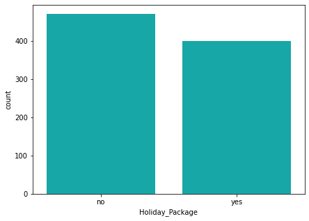

```python
plt.figure(figsize=(7,5))
sns.countplot(x="Holiday_Package", data=holiday, color="c")
```

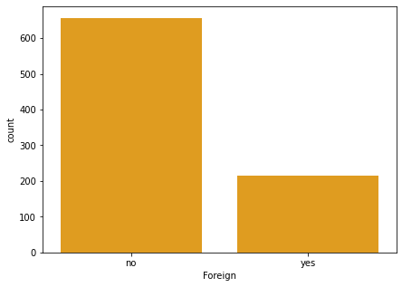

```python
plt.figure(figsize=(7,5))
sns.countplot(x="Foreign", data=holiday, color="orange")
```